# Computational Musicology Portfolio

Aram Elias

Feb 14, 2021

```r
knitr::opts_chunk$set(echo = TRUE)
library(tidyverse)
```

```r
library(spotifyr)
library(ggplot2)
```

# Analysis: Ayreon

Dutch progressive-metal band, *Ayreon*, has released six concept albums between 1995 and 2017 that are known for their unique sound. It may be worthwhile to compare these albums to one another to see how the band has developed over time.

Some songs in different albums reference one another, and for these it could also be interesting to see how much they have in common musically speaking. Some other songs are considered outliers due to not sounding the same as the rest of the album, or even having more in common with other albums to the human ear.

With most songs being over five minutes in length and having distinct musical segments with complex rhythms, and each album consisting of about fifteen songs, a large amount of data on this band is available on Spotify.

A limitation of this corpus would be a lack of other material to compare it with; however, with the band citing older bands such as Pink Floyd as inspiration, looking into similarities there might also be a good avenue for research.

```r
# Retrieve data
ayreon <- get_playlist_audio_features("", "3O1z9gRNz9DiB9wujbgLiV")

# Remove stray song
ayreon <- subset(ayreon, track.album.name != "Timeline")

# Remove unnecessary columns (mostly empty or irrelevant to the music itself)
ayreon <- subset(ayreon, select = -c(playlist_id, playlist_name, playlist_img, playlist_owner_name, playlist_owner_id,
                  added_at, primary_color, added_by.href, added_by.id, added_by.type, added_by.uri, added_by.external_urls.spotify,
                  track.artists, track.available_markets, track.disc_number, track.episode, track.explicit,
                  is_local, track.is_local, track.preview_url, track.track, track.type, video_thumbnail.url, mode,
                  track.album.album_type, track.album.artists, track.album.available_markets, track.album.href,
                  track.album.id, track.album.images, track.album.release_date_precision, track.album.type))

# Clean up some album names
ayreon$track.album.name[ayreon$track.album.name == "The Final Experiment (Special Edition)"] <- "The Final Experiment"
ayreon$track.album.name[ayreon$track.album.name == "Universal Migrator Pt.1 & 2"] <- "Universal Migrator"
ayreon$mode_name <- ifelse(ayreon$mode_name == "minor", "Minor", "Major")

# Put the albums in chronological order using a factor
ayreon$album_factor = factor(ayreon$track.album.name, levels = c("The Final Experiment", "Into The Electric Castle",
                                                                 "Universal Migrator", "The Human Equation",
                                                                 "01011001", "The Source"))

ayreon
```

```
## # A tibble: 104 x 30
##    danceability energy   key loudness speechiness acousticness instrumentalness
##           <dbl>  <dbl> <int>    <dbl>       <dbl>        <dbl>            <dbl>
##  1        0.233  0.434     9   -13.8       0.198      0.202           0.102
##  2        0.403  0.457     0   -11.1       0.0489     0.0176          0.00316
##  3        0.439  0.861     1    -8.12      0.0489     0.00083         0.000564
##  4        0.239  0.69      2   -10.0       0.0475     0.00374         0.0647
##  5        0.471  0.203     4   -19.4       0.0374     0.744           0
##  6        0.25   0.643     4    -9.41      0.034      0.000897        0.000395
##  7        0.466  0.278     2   -16.7       0.051      0.415           0.00118
##  8        0.452  0.532     6   -11.5       0.0589     0.00598         0.0000358
##  9        0.204  0.608    11   -10.5       0.0517     0.00282         0.0147
## 10        0.368  0.491     2   -10.6       0.0336     0.00104         0.00419
## # … with 94 more rows, and 23 more variables: liveness <dbl>, valence <dbl>,
## #   tempo <dbl>, track.id <chr>, analysis_url <chr>, time_signature <int>,
## #   track.duration_ms <int>, track.href <chr>, track.name <chr>,
## #   track.popularity <int>, track.track_number <int>, track.uri <chr>,
## #   track.album.name <chr>, track.album.release_date <chr>,
## #   track.album.total_tracks <int>, track.album.uri <chr>,
## #   track.album.external_urls.spotify <chr>, track.external_ids.isrc <chr>,
## #   track.external_urls.spotify <chr>, key_name <chr>, mode_name <chr>,
## #   key_mode <chr>, album_factor <fct>
```

# Plotting

This plot is an overview of Ayreon’s six albums, in chronological order. The valence and energy are plotted against each other on the axes, while the size of the circle represents loudness and the color represents the mode.

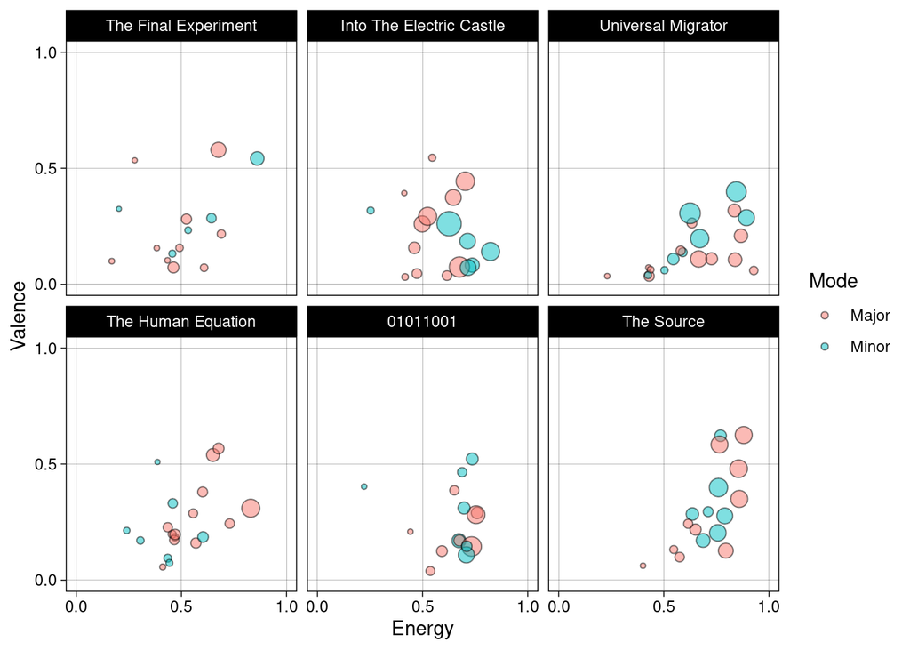

```r
ggplot(ayreon, aes(x = energy, y = valence, size = loudness, fill = mode_name)) +
  geom_point(shape = 21, color = "#000000", alpha = 0.5) +
  scale_x_continuous(limits = c(0, 1), breaks = c(0, 0.5, 1), minor_breaks = NULL) +
  scale_y_continuous(limits = c(0, 1), breaks = c(0, 0.5, 1), minor_breaks = NULL) +
  scale_size_continuous(trans = "exp", guide = "none") +
  facet_wrap(~album_factor) +
  theme_linedraw() +
  labs(x = "Energy", y = "Valence", size = "Loudness", fill = "Mode")
```

This plot shows that, especially through time, the band has gravitated towards higher-energy tracks with low to medium valence, and tracks have also become louder on average. Major-mode tracks also tend to have a higher energy and valence, but this is more clearly visible in later albums than in earlier ones.